# Projektbeschreibung: Bildklassifikation, Transfer Learning und Data Augmentation mit CIFAR-10

Einführung: In einer Welt, die von visuellen Informationen geprägt ist, ist die Fähigkeit, Bilder effizient zu analysieren und zu klassifizieren, von entscheidender Bedeutung. Dieses Projekt widmet sich der Herausforderung der Bildklassifikation und geht noch einen Schritt weiter, um unausgeglichene Klassen durch Data Augmentation auszugleichen. Der CIFAR-10-Datensatz, bestehend aus 60.000 Bildern in zehn verschiedenen Klassen, bildet die Grundlage dieses Vorhabens. Unsere Mission beginnt mit einer Multi-Klassen-Klassifikation, bei der ein Convolutional Neural Network (CNN) trainiert wird, um Bilder in die richtigen Kategorien zu klassifizieren, dann am Schluss Transfer Learning anwenden. Doch das ist erst der Anfang. Wir werden das leistungsstärkste Modell identifizieren und die dazugehörige Klasse als positive Klasse für eine binäre Klassifikation wählen. Die anderen Klassen werden zu unseren negativen Klassen. Aber hier kommt die Herausforderung: Unausgeglichene Klassen erfordern eine kluge Herangehensweise. Daher werde ich Data Augmentation verwenden, um synthetische Beispiele für die ausgewählte Klasse zu generieren und so das Modell zu verbessern. Diese Fusion aus Multi-Klassen- und binärer Klassifikation sowie die Integration von Data Augmentation versprechen ein spannendes Projekt, bei dem ich meine Fähigkeiten im Bereich Deep Learning, Bildverarbeitung und Datenanalyse vertiefen werde. Die Ergebnisse werden nicht nur Erkenntnisse über die Anwendung von Transfer Learning und Data Augmentation liefern, sondern auch die Möglichkeiten der Bildklassifikation in realen Szenarien aufzeigen. Willkommen in einer aufregenden Reise zur Bildklassifikation und Datenanreicherung!

# Schritt 1: Datensatz erkunden

Der CIFAR-10-Datensatz besteht aus 60.000 32x32-Farbbildern in 10 Klassen mit 6.000 Bildern pro Klasse. Es gibt 50.000 Trainingsbilder und 10.000 Testbilder.

Der Datensatz ist in fünf Trainingsstapel und einen Teststapel mit jeweils 10.000 Bildern unterteilt. Der Teststapel enthält genau 1000 zufällig ausgewählte Bilder aus jeder Klasse. Die Trainingsstapel enthalten die verbleibenden Bilder in zufälliger Reihenfolge, einige Trainingsstapel enthalten jedoch möglicherweise mehr Bilder aus einer Klasse als aus einer anderen. Insgesamt enthalten die Trainingsstapel genau 5000 Bilder aus jeder Klasse.

```python
import numpy as np
import seaborn as sns
import matplotlib.pyplot as plt
from keras.datasets import cifar10
from keras.utils import to_categorical
from keras.models import Sequential
from keras.layers import Dense, Dropout, Flatten, Conv2D, MaxPooling2D, BatchNormalization
from sklearn.metrics import confusion_matrix
from keras.preprocessing.image import ImageDataGenerator
from tensorflow import keras
from sklearn.metrics import classification_report
import tensorflow as tf
from tensorflow.keras.callbacks import EarlyStopping
from keras.applications import MobileNet
from keras.applications import ResNet50
from keras.models import Model
from keras.layers import Dense, GlobalAveragePooling2D
```

```python
# Laden des CIFAR-10-Datasets
(X_train, y_train), (X_test, y_test) = cifar10.load_data()

# Ausgabe der Formen der Datensätze
print((X_train.shape, y_train.shape))
print((X_test.shape, y_test.shape))
```

```
((50000, 32, 32, 3), (50000, 1))
((10000, 32, 32, 3), (10000, 1))
```

```
Label: [6]
```

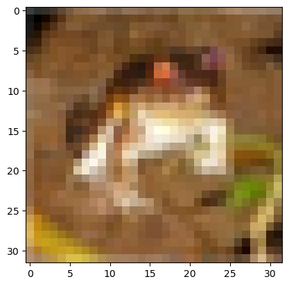

```python
print("Label:", y_train[0])
plt.imshow(X_train[0])
plt.show()
```

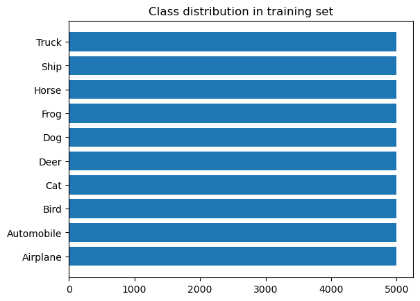

```python
# klassen Trainingsgrößen plotten
classes_name = ['Airplane', 'Automobile', 'Bird', 'Cat', 'Deer', 'Dog', 'Frog', 'Horse', 'Ship', 'Truck']

classes, counts = np.unique(y_train, return_counts=True)
plt.barh(classes_name, counts)
plt.title('Class distribution in training set')
```

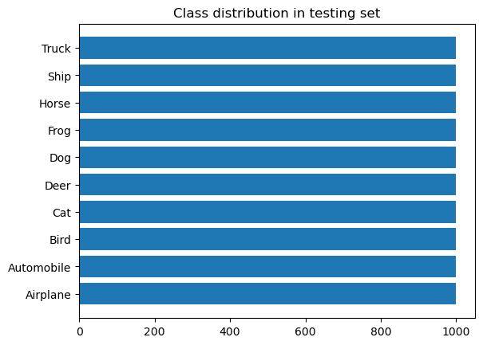

```python
# klassen Testgrößen plotten
classes, counts = np.unique(y_test, return_counts=True)
plt.barh(classes_name, counts)
plt.title('Class distribution in testing set')
```

# Schritt 2: Multi-Klassen-Klassifikation

• Erstellung ein Convolutional Neural Network (CNN), um die Bilder in 10 verschiedene Klassen zu klassifizieren.

```python
# Normalisierung der Bildpixel auf den Bereich [0, 1]
X_train = X_train.astype(np.float32) / 255.
X_test = X_test.astype(np.float32) / 255.
```

```python
# Anzahl der Klassen in Ihrem Datensatz (in CIFAR-10 sind es 10)
num_classes = 10

# Zielvariablen in One-Hot-kodierte Vektoren umwandeln
y_train = to_categorical(y_train, num_classes)
y_test = to_categorical(y_test, num_classes)
```

```python
# Das Modell designen
model = Sequential()
model.add(Conv2D(32, kernel_size=(3, 3), input_shape=(32, 32, 3), activation="relu"))
model.add(MaxPooling2D(pool_size=(2, 2)))
model.add(Dropout(0.2))

model.add(Conv2D(64, kernel_size=(3, 3), activation="relu"))
model.add(MaxPooling2D(pool_size=(2, 2)))
model.add(Dropout(0.2))

model.add(Flatten())
model.add(Dense(128, activation="relu"))
model.add(Dense(10, activation="softmax"))

model.compile(optimizer="rmsprop", loss='categorical_crossentropy', metrics=["accuracy"])
model.summary()

history = model.fit(X_train, y_train, batch_size=150, epochs=10, validation_data=(X_test, y_test))
```

```
Model: "sequential"
_________________________________________________________________
 Layer (type)                Output Shape              Param #
=================================================================
 conv2d (Conv2D)             (None, 30, 30, 32)        896

 max_pooling2d (MaxPooling2  (None, 15, 15, 32)        0
 D)

 dropout (Dropout)           (None, 15, 15, 32)        0

 conv2d_1 (Conv2D)           (None, 13, 13, 64)        18496

 max_pooling2d_1 (MaxPoolin  (None, 6, 6, 64)          0
 g2D)

 dropout_1 (Dropout)         (None, 6, 6, 64)          0

 flatten (Flatten)           (None, 2304)              0

 dense (Dense)               (None, 128)               295040

 dense_1 (Dense)             (None, 10)                1290

=================================================================
Total params: 315722 (1.20 MB)
Trainable params: 315722 (1.20 MB)
Non-trainable params: 0 (0.00 Byte)
_________________________________________________________________
```

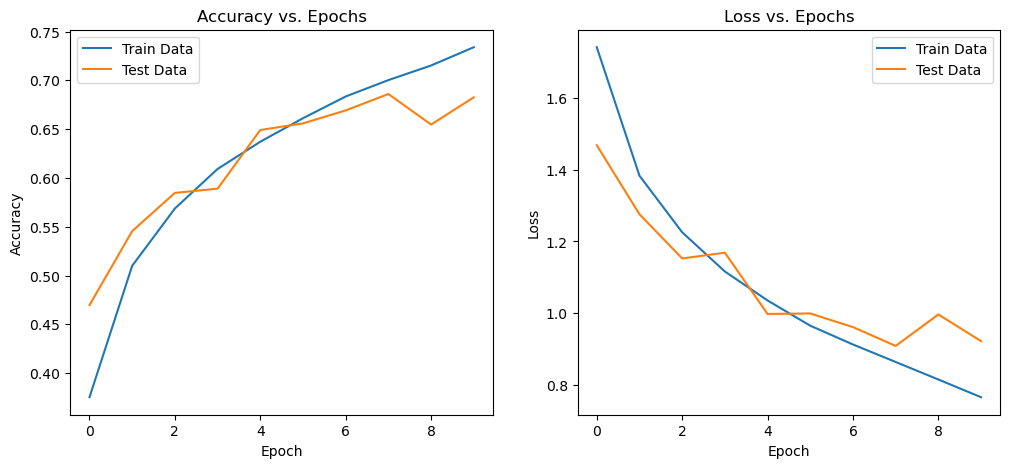

```python
# Trainingsergebnisse visualisieren (Genauigkeit und Verlust)
plt.figure(figsize=(12, 5))
plt.subplot(1, 2, 1)
plt.plot(history.history['accuracy'], label='Train Data')
plt.plot(history.history['val_accuracy'], label='Test Data')
plt.legend()
plt.xlabel('Epoch')
plt.ylabel('Accuracy')
plt.title('Accuracy vs. Epochs')

plt.subplot(1, 2, 2)
plt.plot(history.history['loss'], label='Train Data')
plt.plot(history.history['val_loss'], label='Test Data')
plt.legend()
plt.xlabel('Epoch')
plt.ylabel('Loss')
plt.title('Loss vs. Epochs')

plt.show()
```

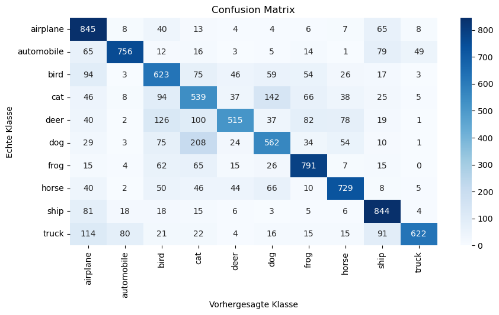

```python
# Vorhersagen für die Testdaten erhalten
y_pred = model.predict(X_test)

# Konvertierung der Vorhersagen in Klassenindizes
y_pred_classes = np.argmax(y_pred, axis=1)
y_true_classes = np.argmax(y_test, axis=1)

# Klassenbeschriftungen Definieren
class_names = ['airplane', 'automobile', 'bird', 'cat', 'deer', 'dog', 'frog', 'horse', 'ship', 'truck']

# Confusion Matrix erstellen
confusion_mtx = confusion_matrix(y_true_classes, y_pred_classes)

# Die Confusion Matrix visualisieren
plt.figure(figsize=(10, 5))
sns.heatmap(confusion_mtx, annot=True, fmt='d', cmap='Blues', xticklabels=class_names, yticklabels=class_names)
plt.xlabel('Vorhergesagte Klasse')
plt.ylabel('Echte Klasse')
plt.title('Confusion Matrix')
plt.show()
```

```python
# Berechnung des Klassifikationsbericht
classification_rep = classification_report(y_true_classes, y_pred_classes, target_names=class_names)

# Klassifikationsbericht
print(classification_rep)
```

```
              precision    recall  f1-score   support

    airplane       0.62      0.84      0.71      1000
  automobile       0.86      0.76      0.80      1000
        bird       0.56      0.62      0.59      1000
         cat       0.49      0.54      0.51      1000
        deer       0.74      0.52      0.61      1000
         dog       0.61      0.56      0.59      1000
        frog       0.73      0.79      0.76      1000
       horse       0.76      0.73      0.74      1000
        ship       0.72      0.84      0.78      1000
       truck       0.89      0.62      0.73      1000

    accuracy                           0.68     10000
   macro avg       0.70      0.68      0.68     10000
weighted avg       0.70      0.68      0.68     10000
```

```python
# Das Modell designen
model = Sequential()
model.add(Conv2D(32, kernel_size=(3, 3), input_shape=(32, 32, 3), activation="relu"))
model.add(MaxPooling2D(pool_size=(2, 2)))
model.add(Dropout(0.2))

model.add(Conv2D(64, kernel_size=(3, 3), activation="relu"))
model.add(MaxPooling2D(pool_size=(2, 2)))
model.add(Dropout(0.2))

model.add(Flatten())
model.add(Dense(128, activation="relu"))
model.add(Dense(10, activation="softmax"))

model.compile(optimizer="adam", loss='categorical_crossentropy', metrics=["accuracy"])
model.summary()

history = model.fit(X_train, y_train, batch_size=150, epochs=10, validation_data=(X_test, y_test))
```

```
Model: "sequential_1"
_________________________________________________________________
 Layer (type)                Output Shape              Param #
=================================================================
 conv2d_2 (Conv2D)           (None, 30, 30, 32)        896

 max_pooling2d_2 (MaxPoolin  (None, 15, 15, 32)        0
 g2D)

 dropout_2 (Dropout)         (None, 15, 15, 32)        0

 conv2d_3 (Conv2D)           (None, 13, 13, 64)        18496

 max_pooling2d_3 (MaxPoolin  (None, 6, 6, 64)          0
 g2D)

 dropout_3 (Dropout)         (None, 6, 6, 64)          0

 flatten_1 (Flatten)         (None, 2304)              0

 dense_2 (Dense)             (None, 128)               295040

 dense_3 (Dense)             (None, 10)                1290

=================================================================
Total params: 315722 (1.20 MB)
Trainable params: 315722 (1.20 MB)
Non-trainable params: 0 (0.00 Byte)
_________________________________________________________________
```

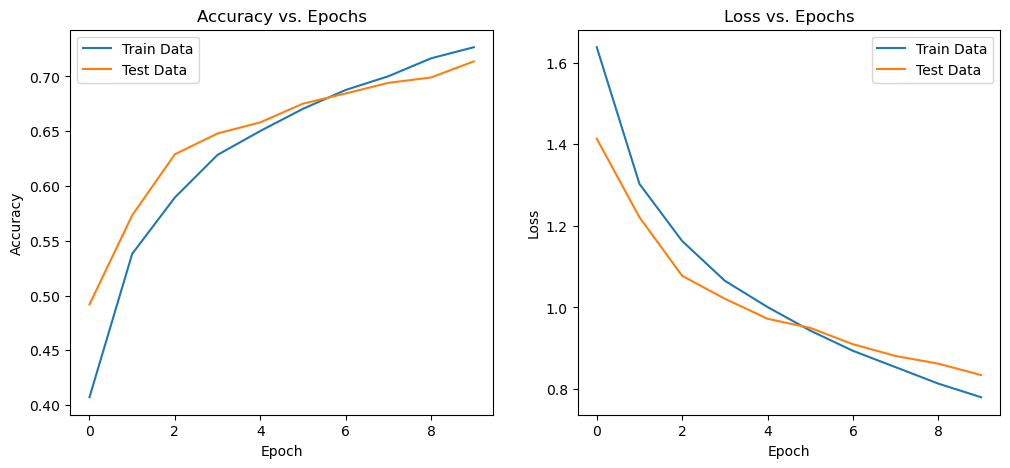

```python
# Trainingsergebnisse visualisieren (Genauigkeit und Verlust)
plt.figure(figsize=(12, 5))
plt.subplot(1, 2, 1)
plt.plot(history.history['accuracy'], label='Train Data')
plt.plot(history.history['val_accuracy'], label='Test Data')
plt.legend()
plt.xlabel('Epoch')
plt.ylabel('Accuracy')
plt.title('Accuracy vs. Epochs')

plt.subplot(1, 2, 2)
plt.plot(history.history['loss'], label='Train Data')
plt.plot(history.history['val_loss'], label='Test Data')
plt.legend()
plt.xlabel('Epoch')
plt.ylabel('Loss')
plt.title('Loss vs. Epochs')

plt.show()
```

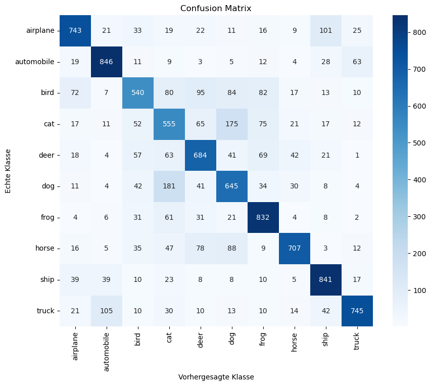

```python
# Vorhersagen für die Testdaten erhalten
y_pred = model.predict(X_test)

# Konvertierung der Vorhersagen in Klassenindizes
y_pred_classes = np.argmax(y_pred, axis=1)
y_true_classes = np.argmax(y_test, axis=1)

# Klassenbeschriftungen Definieren
class_names = ['airplane', 'automobile', 'bird', 'cat', 'deer', 'dog', 'frog', 'horse', 'ship', 'truck']

# Confusion Matrix erstellen
confusion_mtx = confusion_matrix(y_true_classes, y_pred_classes)

# Die Confusion Matrix visualisieren
plt.figure(figsize=(10, 8))
sns.heatmap(confusion_mtx, annot=True, fmt='d', cmap='Blues', xticklabels=class_names, yticklabels=class_names)
plt.xlabel('Vorhergesagte Klasse')
plt.ylabel('Echte Klasse')
plt.title('Confusion Matrix')
plt.show()
```

```python
# Berechnung des Klassifikationsbericht
classification_rep = classification_report(y_true_classes, y_pred_classes, target_names=class_names)

# Klassifikationsbericht
print(classification_rep)
```

[output not shown]

```python
# Das Modell designen
model = Sequential()
model.add(Conv2D(32, kernel_size=(3, 3), input_shape=(32, 32, 3), activation="relu"))
model.add(MaxPooling2D(pool_size=(2, 2)))
model.add(Dropout(0.25))

model.add(Conv2D(64, kernel_size=(3, 3), activation="relu"))
model.add(MaxPooling2D(pool_size=(2, 2)))
model.add(Dropout(0.25))

model.add(Conv2D(128, kernel_size=(3, 3), activation="relu"))
model.add(MaxPooling2D(pool_size=(2, 2)))
model.add(Dropout(0.25))

model.add(Flatten())
model.add(Dense(256, activation="relu"))
model.add(Dense(10, activation="softmax"))

model.compile(optimizer="adam", loss='categorical_crossentropy', metrics=["accuracy"])
model.summary()

early_stop = EarlyStopping(monitor='val_loss',patience=10)
history = model.fit(X_train, y_train, batch_size=150, epochs=50, validation_data=(X_test, y_test),callbacks=[early_stop])
```

```
Model: "sequential_2"
_________________________________________________________________
 Layer (type)                Output Shape              Param #
=================================================================
 conv2d_4 (Conv2D)           (None, 30, 30, 32)        896

 max_pooling2d_4 (MaxPoolin  (None, 15, 15, 32)        0
 g2D)

 dropout_4 (Dropout)         (None, 15, 15, 32)        0

 conv2d_5 (Conv2D)           (None, 13, 13, 64)        18496

 max_pooling2d_5 (MaxPoolin  (None, 6, 6, 64)          0
 g2D)

 dropout_5 (Dropout)         (None, 6, 6, 64)          0

 conv2d_6 (Conv2D)           (None, 4, 4, 128)         73856

 max_pooling2d_6 (MaxPoolin  (None, 2, 2, 128)         0
 g2D)

 dropout_6 (Dropout)         (None, 2, 2, 128)         0

 flatten_2 (Flatten)         (None, 512)               0

 dense_4 (Dense)             (None, 256)               131328

 dense_5 (Dense)             (None, 10)                2570

=================================================================
Total params: 227146 (887.29 KB)
Trainable params: 227146 (887.29 KB)
Non-trainable params: 0 (0.00 Byte)
_________________________________________________________________
```

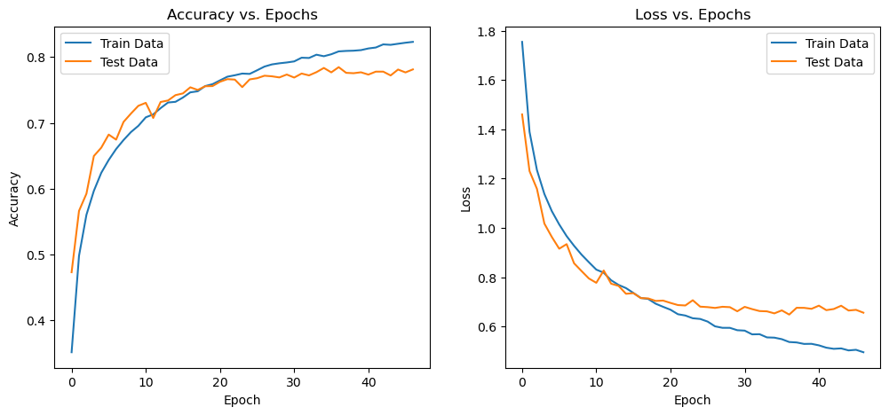

```python
# Trainingsergebnisse visualisieren (Genauigkeit und Verlust)
plt.figure(figsize=(12, 5))
plt.subplot(1, 2, 1)
plt.plot(history.history['accuracy'], label='Train Data')
plt.plot(history.history['val_accuracy'], label='Test Data')
plt.legend()
plt.xlabel('Epoch')
plt.ylabel('Accuracy')
plt.title('Accuracy vs. Epochs')

plt.subplot(1, 2, 2)
plt.plot(history.history['loss'], label='Train Data')
plt.plot(history.history['val_loss'], label='Test Data')
plt.legend()
plt.xlabel('Epoch')
plt.ylabel('Loss')
plt.title('Loss vs. Epochs')

plt.show()
```

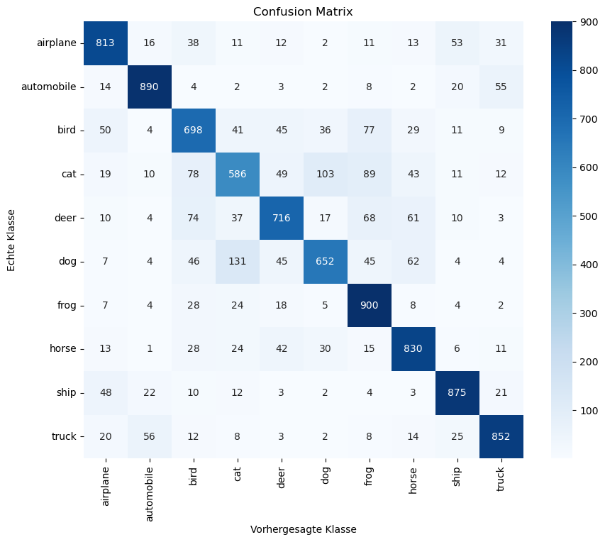

```python
# Vorhersagen für die Testdaten erhalten
y_pred = model.predict(X_test)

# Konvertierung der Vorhersagen in Klassenindizes
y_pred_classes = np.argmax(y_pred, axis=1)
y_true_classes = np.argmax(y_test, axis=1)

# Klassenbeschriftungen Definieren
class_names = ['airplane', 'automobile', 'bird', 'cat', 'deer', 'dog', 'frog', 'horse', 'ship', 'truck']

# Confusion Matrix erstellen
confusion_mtx = confusion_matrix(y_true_classes, y_pred_classes)

# Die Confusion Matrix visualisieren
plt.figure(figsize=(10, 8))
sns.heatmap(confusion_mtx, annot=True, fmt='d', cmap='Blues', xticklabels=class_names, yticklabels=class_names)
plt.xlabel('Vorhergesagte Klasse')
plt.ylabel('Echte Klasse')
plt.title('Confusion Matrix')
plt.show()
```

```python
# Berechnung des Klassifikationsbericht
classification_rep = classification_report(y_true_classes, y_pred_classes, target_names=class_names)

# Klassifikationsbericht
print(classification_rep)
```

```
              precision    recall  f1-score   support

    airplane       0.81      0.81      0.81      1000
  automobile       0.88      0.89      0.89      1000
        bird       0.69      0.70      0.69      1000
         cat       0.67      0.59      0.62      1000
        deer       0.76      0.72      0.74      1000
         dog       0.77      0.65      0.70      1000
        frog       0.73      0.90      0.81      1000
       horse       0.78      0.83      0.80      1000
        ship       0.86      0.88      0.87      1000
       truck       0.85      0.85      0.85      1000

    accuracy                           0.78     10000
   macro avg       0.78      0.78      0.78     10000
weighted avg       0.78      0.78      0.78     10000
```

```python
# eigene-Modell in einer Datei Speichern
# model.save('CIFAR10_eigene_model.h5')

# eigene-Modell aus der Datei Laden
# model = keras.models.load_model('CIFAR10_resnet_model.h5')
```

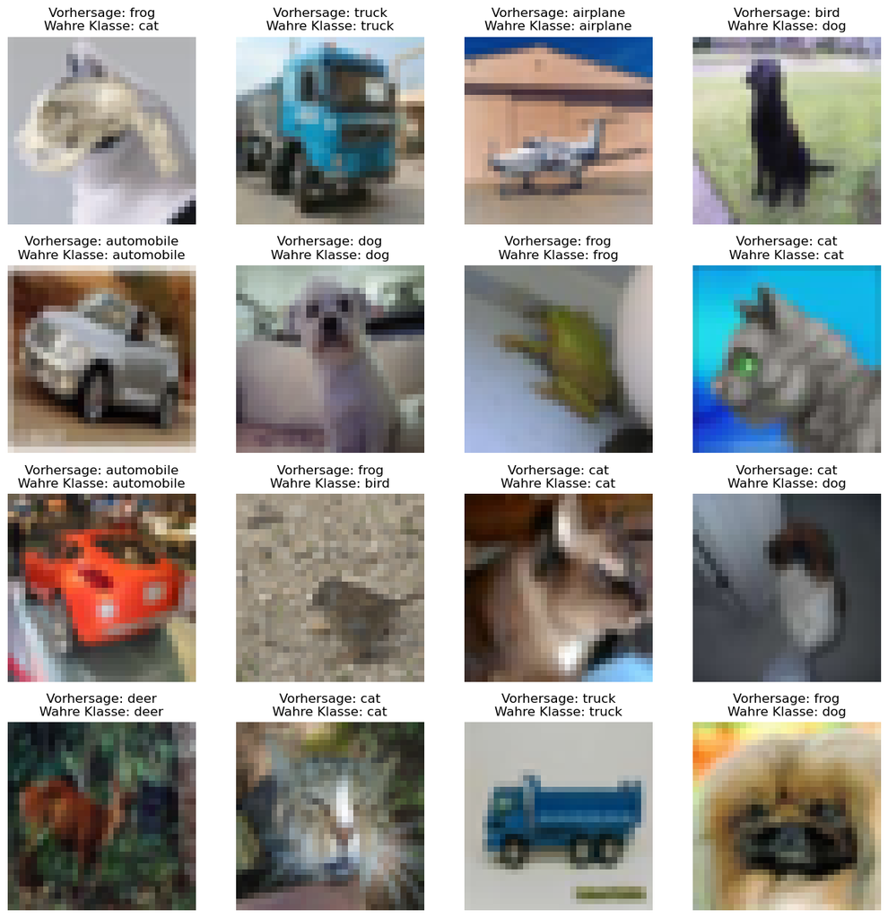

```python
# Anzahl der Bilder, die Sie anzeigen möchten (4x4 Raster)
num_rows = 4
num_cols = 4
num_images_to_display = num_rows * num_cols

# Zufällige Indizes auswählen, um Bilder aus den Testdaten auszuwählen
random_indices = np.random.choice(len(X_test), num_images_to_display)

# Vorhersagen und wahre Klassen für die ausgewählten Bilder erhalten
predicted_classes = y_pred_classes[random_indices]
true_classes = y_true_classes[random_indices]

# Bilder, Vorhersagen und wahre Klassen in einem 4x4-Raster anzeigen
plt.figure(figsize=(12, 12))
for i, index in enumerate(random_indices):
    plt.subplot(num_rows, num_cols, i + 1)
    plt.imshow(X_test[index])
    plt.title(f"Vorhersage: {class_names[predicted_classes[i]]}\nWahre Klasse: {class_names[true_classes[i]]}")
    plt.axis('off')

plt.tight_layout()
plt.show()
```

```python
INPUT_SHAPE = (32, 32, 3)
KERNEL_SIZE = (3, 3)
model = Sequential()

# Convolutional Layer
model.add(Conv2D(filters=32, kernel_size=KERNEL_SIZE, input_shape=INPUT_SHAPE, activation='relu', padding='same'))
model.add(BatchNormalization())
model.add(Conv2D(filters=32, kernel_size=KERNEL_SIZE, input_shape=INPUT_SHAPE, activation='relu', padding='same'))
model.add(BatchNormalization())
# Pooling layer
model.add(MaxPooling2D(pool_size=(2, 2)))
# Dropout layers
model.add(Dropout(0.25))

model.add(Conv2D(filters=64, kernel_size=KERNEL_SIZE, input_shape=INPUT_SHAPE, activation='relu', padding='same'))
model.add(BatchNormalization())
model.add(Conv2D(filters=64, kernel_size=KERNEL_SIZE, input_shape=INPUT_SHAPE, activation='relu', padding='same'))
model.add(BatchNormalization())
model.add(MaxPooling2D(pool_size=(2, 2)))
model.add(Dropout(0.25))

model.add(Conv2D(filters=128, kernel_size=KERNEL_SIZE, input_shape=INPUT_SHAPE, activation='relu', padding='same'))
model.add(BatchNormalization())
model.add(Conv2D(filters=128, kernel_size=KERNEL_SIZE, input_shape=INPUT_SHAPE, activation='relu', padding='same'))
model.add(BatchNormalization())
model.add(MaxPooling2D(pool_size=(2, 2)))
model.add(Dropout(0.25))

model.add(Flatten())
# model.add(Dropout(0.2))
model.add(Dense(128, activation='relu'))
model.add(Dropout(0.25))
model.add(Dense(10, activation='softmax'))

METRICS = [
    'accuracy',
    tf.keras.metrics.Precision(name='precision'),
    tf.keras.metrics.Recall(name='recall')
]
model.compile(loss='categorical_crossentropy', optimizer='adam', metrics=METRICS)

model.summary()
```

```
Model: "sequential_4"
_________________________________________________________________
 Layer (type)                Output Shape              Param #
=================================================================
 conv2d_16 (Conv2D)          (None, 32, 32, 32)        896

 batch_normalization_16 (Ba  (None, 32, 32, 32)        128
 tchNormalization)

 conv2d_17 (Conv2D)          (None, 32, 32, 32)        9248

 batch_normalization_17 (Ba  (None, 32, 32, 32)        128
 tchNormalization)

 max_pooling2d_6 (MaxPoolin  (None, 16, 16, 32)        0
 g2D)

 dropout_8 (Dropout)         (None, 16, 16, 32)        0

 conv2d_18 (Conv2D)          (None, 16, 16, 64)        18496

 batch_normalization_18 (Ba  (None, 16, 16, 64)        256
 tchNormalization)

 conv2d_19 (Conv2D)          (None, 16, 16, 64)        36928

 batch_normalization_19 (Ba  (None, 16, 16, 64)        256
 tchNormalization)

 max_pooling2d_7 (MaxPoolin  (None, 8, 8, 64)          0
 g2D)

 dropout_9 (Dropout)         (None, 8, 8, 64)          0

 conv2d_20 (Conv2D)          (None, 8, 8, 128)         73856

 batch_normalization_20 (Ba  (None, 8, 8, 128)         512
 tchNormalization)

 conv2d_21 (Conv2D)          (None, 8, 8, 128)         147584

 batch_normalization_21 (Ba  (None, 8, 8, 128)         512
 tchNormalization)

 max_pooling2d_8 (MaxPoolin  (None, 4, 4, 128)         0
 g2D)

 dropout_10 (Dropout)        (None, 4, 4, 128)         0

 flatten_2 (Flatten)         (None, 2048)              0

 dense_4 (Dense)             (None, 128)               262272

 dropout_11 (Dropout)        (None, 128)               0

 dense_5 (Dense)             (None, 10)                1290

=================================================================
Total params: 552362 (2.11 MB)
Trainable params: 551466 (2.10 MB)
Non-trainable params: 896 (3.50 KB)
_________________________________________________________________
```

```python
early_stop = EarlyStopping(monitor='val_loss',patience=5)
history = model.fit(X_train, y_train, batch_size=150, epochs=50, validation_data=(X_test, y_test),callbacks=[early_stop])
```

# Schritt 3: Transfer Learning

• Verschiedene CNN-Architekturen (z. B. MobileNet, ResNet) ausprobieren und Hyperparameter optimieren, um die beste Leistung zu erzielen.

```python
# Laden des vortrainierten MobileNet-Modells ohne die oberste Schicht (top=False)
base_model = MobileNet(weights='imagenet', include_top=False, input_shape=(32, 32, 3))

# Neues Modell erstellen und die Schichten des MobileNet-Modells hinzufügen
new_model = Sequential()
new_model.add(base_model)
new_model.add(GlobalAveragePooling2D())
new_model.add(Dense(256, activation='relu'))
new_model.add(Dropout(0.5))
new_model.add(Dense(10, activation='softmax'))

new_model.compile(optimizer='adam', loss='categorical_crossentropy', metrics=['accuracy'])

early_stop = EarlyStopping(monitor='val_loss',patience=5)
new_history = new_model.fit(X_train, y_train, batch_size=150, epochs=20, validation_data=(X_test, y_test),callbacks=[early_stop])
```

```
WARNING:tensorflow:`input_shape` is undefined or non-square, or `rows` is not in [128, 160, 192, 224]. Weights for input shape (224, 224) will be loaded as the default.
```

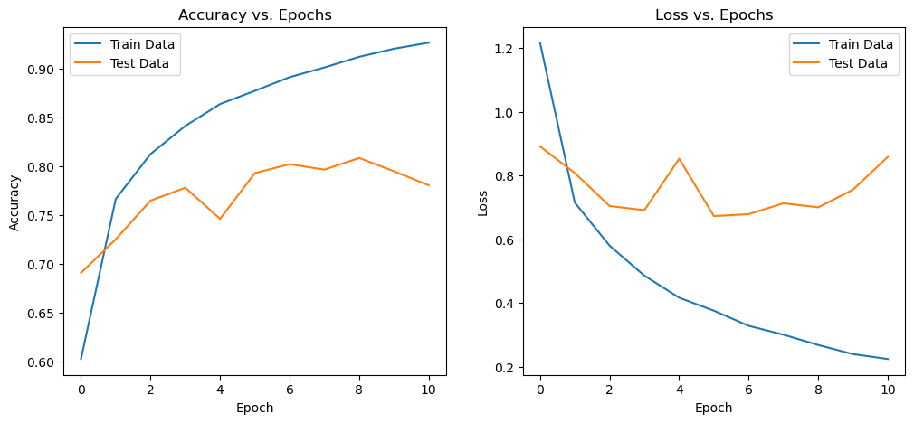

```python
# die Trainingsergebnisse beider Modelle Vergleichen
plt.figure(figsize=(12, 5))
plt.subplot(1, 2, 1)
plt.plot(new_history.history['accuracy'], label='Train Data')
plt.plot(new_history.history['val_accuracy'], label='Test Data')
plt.legend()
plt.xlabel('Epoch')
plt.ylabel('Accuracy')
plt.title('Accuracy vs. Epochs')

plt.subplot(1, 2, 2)
plt.plot(new_history.history['loss'], label='Train Data')
plt.plot(new_history.history['val_loss'], label='Test Data')
plt.legend()
plt.xlabel('Epoch')
plt.ylabel('Loss')
plt.title('Loss vs. Epochs')

plt.show()
```

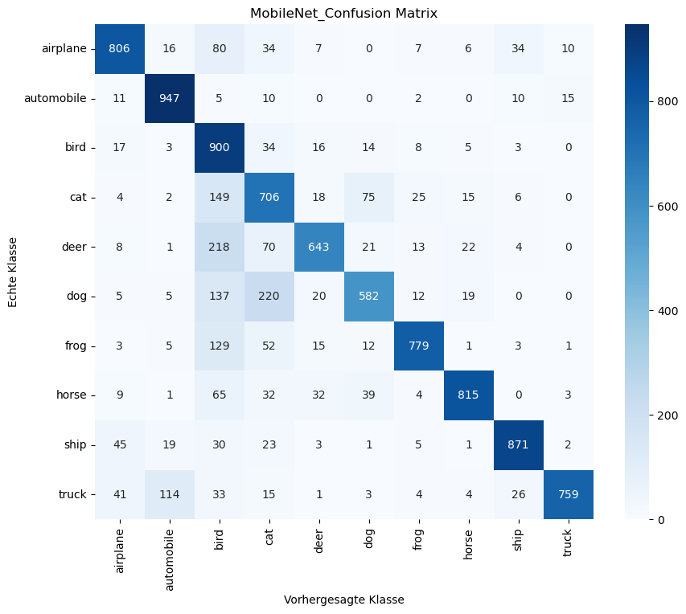

```python
# Vorhersagen für die Testdaten erhalten
y_pred = new_model.predict(X_test)

# Konvertierung der Vorhersagen in Klassenindizes
y_pred_classes = np.argmax(y_pred, axis=1)
y_true_classes = np.argmax(y_test, axis=1)

# die Klassenbeschriftungen Definieren
class_names = ['airplane', 'automobile', 'bird', 'cat', 'deer', 'dog', 'frog', 'horse', 'ship', 'truck']

# Confusion Matrix erstellen
confusion_mtx = confusion_matrix(y_true_classes, y_pred_classes)

# Die Confusion Matrix visualisieren
plt.figure(figsize=(10, 8))
sns.heatmap(confusion_mtx, annot=True, fmt='d', cmap='Blues', xticklabels=class_names, yticklabels=class_names)
plt.xlabel('Vorhergesagte Klasse')
plt.ylabel('Echte Klasse')
plt.title('MobileNet_Confusion Matrix')
plt.show()
```

```python
# Erstellung des Klassifikationsbericht
classification_rep = classification_report(y_true_classes, y_pred_classes, target_names=class_names)

# Klassifikationsbericht
print(classification_rep)
```

```
              precision    recall  f1-score   support

    airplane       0.85      0.81      0.83      1000
  automobile       0.85      0.95      0.90      1000
        bird       0.52      0.90      0.66      1000
         cat       0.59      0.71      0.64      1000
        deer       0.85      0.64      0.73      1000
         dog       0.78      0.58      0.67      1000
        frog       0.91      0.78      0.84      1000
       horse       0.92      0.81      0.86      1000
        ship       0.91      0.87      0.89      1000
       truck       0.96      0.76      0.85      1000

    accuracy                           0.78     10000
   macro avg       0.81      0.78      0.79     10000
weighted avg       0.81      0.78      0.79     10000
```

```python
# Laden des vortrainierten ResNet-50-Modells ohne die oberste Schicht (top=False)
resnet_model = ResNet50(weights='imagenet', include_top=False, input_shape=(32, 32, 3))

# Neues Modell erstellen und die Schichten des ResNet-Modells hinzufügen
res_model = Sequential()
res_model.add(resnet_model)
res_model.add(GlobalAveragePooling2D())  # Hinzufügen einer Global Average Pooling-Schicht
res_model.add(Dense(256, activation='relu'))  # Hinzufügen einer neuen Dichteschicht
res_model.add(Dropout(0.3))
res_model.add(Dense(10, activation='softmax'))

res_model.compile(optimizer='adam', loss='categorical_crossentropy', metrics=['accuracy'])
res_model.summary()

early_stop = EarlyStopping(monitor='val_loss',patience=5)
res_history = res_model.fit(X_train, y_train, batch_size=150, epochs=20, validation_data=(X_test, y_test),callbacks=[early_stop])
```

```
Model: "sequential_6"
_________________________________________________________________
 Layer (type)                Output Shape              Param #
=================================================================
 resnet50 (Functional)       (None, 1, 1, 2048)        23587712

 global_average_pooling2d_3  (None, 2048)              0
  (GlobalAveragePooling2D)

 dense_12 (Dense)            (None, 256)               524544

 dropout_10 (Dropout)        (None, 256)               0

 dense_13 (Dense)            (None, 10)                2570

=================================================================
Total params: 24114826 (91.99 MB)
Trainable params: 24061706 (91.79 MB)
Non-trainable params: 53120 (207.50 KB)
_________________________________________________________________
```

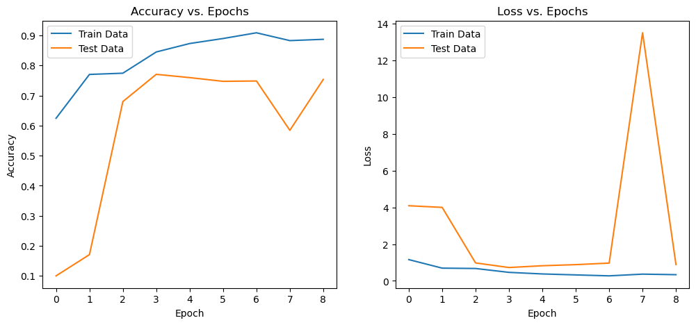

```python
plt.figure(figsize=(12, 5))
plt.subplot(1, 2, 1)
plt.plot(res_history.history['accuracy'], label='Train Data')
plt.plot(res_history.history['val_accuracy'], label='Test Data')
plt.legend()
plt.xlabel('Epoch')
plt.ylabel('Accuracy')
plt.title('Accuracy vs. Epochs')

plt.subplot(1, 2, 2)
plt.plot(res_history.history['loss'], label='Train Data')
plt.plot(res_history.history['val_loss'], label='Test Data')
plt.legend()
plt.xlabel('Epoch')
plt.ylabel('Loss')
plt.title('Loss vs. Epochs')

plt.show()
```

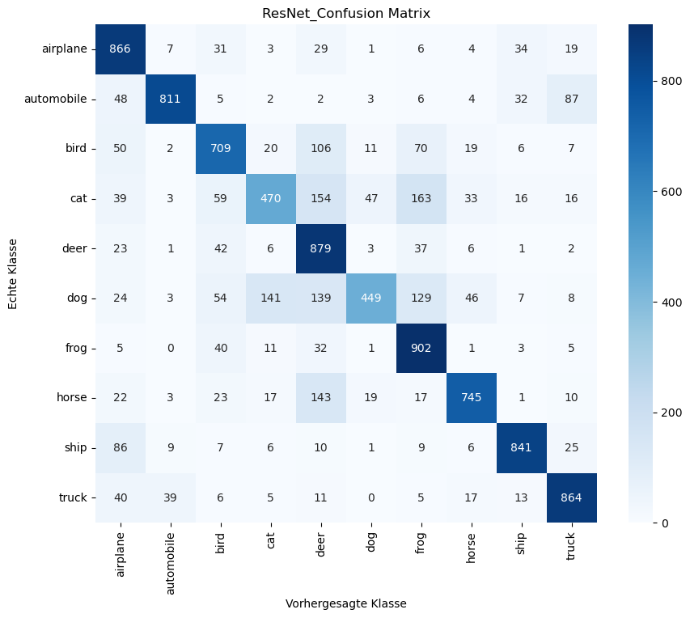

```python
# Vorhersagen für die Testdaten erhalten
y_pred = res_model.predict(X_test)

# Konvertierung der Vorhersagen in Klassenindizes
y_pred_classes = np.argmax(y_pred, axis=1)
y_true_classes = np.argmax(y_test, axis=1)

# Klassenbeschriftungen Definieren
class_names = ['airplane', 'automobile', 'bird', 'cat', 'deer', 'dog', 'frog', 'horse', 'ship', 'truck']

# Confusion Matrix erstellen
confusion_mtx = confusion_matrix(y_true_classes, y_pred_classes)

# Die Confusion Matrix visualisieren
plt.figure(figsize=(10, 8))
sns.heatmap(confusion_mtx, annot=True, fmt='d', cmap='Blues', xticklabels=class_names, yticklabels=class_names)
plt.xlabel('Vorhergesagte Klasse')
plt.ylabel('Echte Klasse')
plt.title('ResNet_Confusion Matrix')
plt.show()
```